# Introduction to Julia

Let's start with a quick overview of the basic syntax, emphasising differences with Python.

Why Jula

- David P. Sanders
- Department of Physics, Faculty of Sciences
- National University of Mexico (UNAM)
- Twitter: @DavidPSanders
- GitHub: dpsanders

# [Variables](http://docs.julialang.org/en/release-0.3/manual/variables/) and arithmetic

Numeric values in Julia work similarly to Python:

Variables in Julia are created as in Python, with a simple assignment operation; variable names can be *arbitrary unicode characters*. Many may be entered in LaTeX notation, using tab substitution: type `\alpha<TAB>`. There is also tab completion on partial names: `\alp<TAB>`

```python
x = 3
```

```
3
```

```python
y = 5
```

```
5
```

```python
α = 3; ℵ = 10
```

```
10
```

Functions use parentheses (round brackets, `()`) around the arguments being passed. `println` prints its arguments, followed by a new line. [`print` omits the new line.]

```python
println("α = ", α)
```

```
α = 3
```

Simple functions may be defined with a nice mathematical syntax; `*` is not needed in simple expressions:

```python
f(x) = 2x^2 + 3x + 1
g(x) = f(x) - (2x+1)*(x+1)
```

```
g (generic function with 1 method)
```

```python
f(3)
```

```
28
```

```python
g(3.5)
```

```
0.0
```

## Variable substitution

The values of variables may be substituted into strings in a simple way using the `$` operator:

```python
# Variable substitution with $:
name = "David"
greeting = "Hello, $name"
println(greeting)
```

```
Hello, David
```

More complicated expressions are wrapped in parentheses:

```python
μ = 3
println("The sine of $μ is $(sin(μ))")
```

```
The sine of 3 is 0.1411200080598672
```

## Numerical types

Machine integers!

```python
a = int(1e16)
a * 10
```

```
100000000000000000
```

```python
a = int8(1)
b = int8(2)
a + b
```

```
3
```

```python
typeof(ans) # ans is the last result
```

```
Int8
```

These promotion rules are defined in `int.jl`.

## Arbitrary-precision arithmetic

Arbitrary-precision integers and floating points are available through the types `BigInt` and `BigFloat`. The function `big` converts a number into the corresponding `Big` type:

```python
big(10)
```

```
10
```

```python
typeof(ans)
```

```
BigInt (constructor with 10 methods)
```

Note that, unlike in Python, integers *are not* automatically promoted to arbitrary-precision integers.

**Exercise**: Calculate powers of 10 using standard integers and `BigInt`s

```python
10^18
```

```
1000000000000000000
```

```python
10**5
```

```
syntax: use "^" instead of "**"
while loading In[16], in expression starting on line 1
```

```python
10^19
```

```
-8446744073709551616
```

```python
ten = big(10)
```

```
10
```

```python
ten^109
```

```
10000000000000000000000000000000000000000000000000000000000000000000000000000000000000000000000000000000000000
```

```python
i = int8(10)
```

```
10
```

```python
i * big(11)
```

```
110
```

```python
typeof(ans)
```

```
BigInt (constructor with 10 methods)
```

```python
typemax(Int64)
```

```
9223372036854775807
```

```python
2^63-1
```

```
9223372036854775807
```

```python
typemin(Int64)
```

```
-9223372036854775808
```

```python
-2^63
```

```
-9223372036854775808
```

## Complex numbers

Complex numbers are written using `im` for the imaginary part:

```python
a = 7
c = (1+3.5im) * a
```

```
7.0 + 24.5im
```

```python
c.im
```

```
24.5
```

```python
c.re, c.im
```

```
(7.0,24.5)
```

```python
c * conj(c)  # conj is a function that returns the conjugate of a complex number
```

```
649.25 + 0.0im
```

(Tuples behave similarly to Python.)

## Rational numbers

Rational numbers are also built into Julia; they are created using the `//` operator:

```python
3//4
```

```
3//4
```

```python
typeof(ans)
```

```
Rational{Int64} (constructor with 1 method)
```

```python
(big(3)//4)^50
```

```
717897987691852588770249//1267650600228229401496703205376
```

```python
typeof(ans)
```

```
Rational{BigInt} (constructor with 1 method)
```

```python
3//4 + 5//6
```

```
19//12
```

Operators are a convenient way of writing functions:

```python
+(3, 4)
```

```
7
```

```python
//(3, 4)
```

```
3//4
```

```python
//
```

```
// (generic function with 8 methods)
```

We see that `//` is a *function*, implemented as a series of *methods*. We can see what these methods are:

```python
methods(//)
```

8 methods for generic function **//**:

- //(n::**Integer**,d::**Integer**) at [rational.jl:15](https://github.com/JuliaLang/julia/tree/687d2b0da6c5e8cff895e8c6f7f8e4b6866b7997/base/rational.jl#L15)

- //(x::**Rational{T<:Integer}**,y::**Integer**) at [rational.jl:16](https://github.com/JuliaLang/julia/tree/687d2b0da6c5e8cff895e8c6f7f8e4b6866b7997/base/rational.jl#L16)

- //(x::**Integer**,y::**Rational{T<:Integer}**) at [rational.jl:17](https://github.com/JuliaLang/julia/tree/687d2b0da6c5e8cff895e8c6f7f8e4b6866b7997/base/rational.jl#L17)

- //(x::**Rational{T<:Integer}**,y::**Rational{T<:Integer}**) at [rational.jl:18](https://github.com/JuliaLang/julia/tree/687d2b0da6c5e8cff895e8c6f7f8e4b6866b7997/base/rational.jl#L18)

- //(x::**Complex{T<:Real}**,y::**Real**) at [rational.jl:19](https://github.com/JuliaLang/julia/tree/687d2b0da6c5e8cff895e8c6f7f8e4b6866b7997/base/rational.jl#L19)

- //(x::**Real**,y::**Complex{T<:Real}**) at [rational.jl:20](https://github.com/JuliaLang/julia/tree/687d2b0da6c5e8cff895e8c6f7f8e4b6866b7997/base/rational.jl#L20)

- //(x::**Complex{T<:Real}**,y::**Complex{T<:Real}**) at [rational.jl:23](https://github.com/JuliaLang/julia/tree/687d2b0da6c5e8cff895e8c6f7f8e4b6866b7997/base/rational.jl#L23)

- //(X::**AbstractArray{T,N}**,y::**Number**) at [rational.jl:28](https://github.com/JuliaLang/julia/tree/687d2b0da6c5e8cff895e8c6f7f8e4b6866b7997/base/rational.jl#L28)

```python
3 + -34
```

```
-31
```

The expression `n::Integer` is a *type annotation* that specifies that the method applies when its first argument is of type `Integer`.

Clicking on the file name takes us directly to the Julia standard library source code on GitHub where these functions are defined!

# Vectors: an "equivalent" of Python lists *and* `numpy` arrays

To store several values "in one variable", we can try to imitate using a "list" as we would in Python:

```python
l = [3, 4, 5]
```

```
3-element Array{Int64,1}:
 3
 4
 5
```

```python
typeof(l)
```

```
Array{Int64,1}
```

In Julia these objects are called `Array`s. The curly braces indicate type parameters of the `Array` type. The first is the type of element contained in the `Array` (all must be of the same type) and the second the number of dimensions.

**Exercise**: Try to create an array in this way with elements of different types. What happens?

**Exercise**: What does the following syntax do?: `l = {3, 4, 7.5}`

```python
l = [3, 4, 7.5]
```

```
3-element Array{Float64,1}:
 3.0
 4.0
 7.5
```

```python
l = [3., 4, 5]
```

```
3-element Array{Float64,1}:
 3.0
 4.0
 5.0
```

```python
l = [3., "a"]
```

```
2-element Array{Any,1}:
 3.0
  "a"
```

```python
l = [3., 'a']
```

```
2-element Array{Float64,1}:
  3.0
 97.0
```

```python
l = {3., 4, "hello", [3, 4]}
```

```
4-element Array{Any,1}:
 3.0
 4
  "hello"
  [3,4]
```

## Indexing

The indices of Julia arrays are numbered starting at 1, unlike Python (where they are numbered starting at 0).

```python
l[1]
```

```
3.0
```

The syntax for ranges is similar to that for Python:

```python
l[1:2]
```

```
2-element Array{Any,1}:
 3.0
 4
```

However, the limits must be explicitly specified:

```python
l[2:end]   # Use `end` explicitly
```

```
3-element Array{Any,1}:
 4
  "hello"
  [3,4]
```

```python
l[1:end-1]
```

```
3-element Array{Any,1}:
 3.0
 4
  "hello"
```

```python
l[-1]
```

```
BoundsError()
while loading In[52], in expression starting on line 1

 in getindex_3B_2413 at /home/tj2/Documents/julia/usr/bin/../lib/julia/sys.so
```

Julia `Arrays`, like Python lists, but unlike `numpy` arrays, are dynamic. However, the syntax is rather different from Python -- to add an element at the end of the list, we write

```python
l = [3,4,5]
l + l
```

```
3-element Array{Int64,1}:
  6
  8
 10
```

```python
names(l)
```

```
0-element Array{Any,1}
```

```python
l = [3, 4, 5]

push!(l, 7)
```

```
4-element Array{Int64,1}:
 3
 4
 5
 7
```

```python
methods(sizehint)
```

11 methods for generic function **sizehint**:

- sizehint(a::**Array{T,1}**,sz::**Integer**) at [array.jl:495](https://github.com/JuliaLang/julia/tree/687d2b0da6c5e8cff895e8c6f7f8e4b6866b7997/base/array.jl#L495)

- sizehint(B::**BitArray{1}**,sz::**Integer**) at [bitarray.jl:514](https://github.com/JuliaLang/julia/tree/687d2b0da6c5e8cff895e8c6f7f8e4b6866b7997/base/bitarray.jl#L514)

- sizehint(s::**IntSet**,top::**Integer**) at [intset.jl:18](https://github.com/JuliaLang/julia/tree/687d2b0da6c5e8cff895e8c6f7f8e4b6866b7997/base/intset.jl#L18)

- sizehint(d::**Dict{K,V}**,newsz) at [dict.jl:445](https://github.com/JuliaLang/julia/tree/687d2b0da6c5e8cff895e8c6f7f8e4b6866b7997/base/dict.jl#L445)

- sizehint(s::**Set{T}**,newsz) at [set.jl:29](https://github.com/JuliaLang/julia/tree/687d2b0da6c5e8cff895e8c6f7f8e4b6866b7997/base/set.jl#L29)

- sizehint(d::**HashDict{K,V,O<:Union(Int64,Void)}**,newsz) at [/home/tj2/.julia/v0.4/DataStructures/src/hashdict.jl:224](https://github.com/JuliaLang/DataStructures.jl/tree/b4aea82ce1cf165b96115f9271efd33776435fe0/src/hashdict.jl#L224)

- sizehint(::**OrderedDict{K,V}**,...) at [/home/tj2/.julia/v0.4/DataStructures/src/delegate.jl:11](https://github.com/JuliaLang/DataStructures.jl/tree/b4aea82ce1cf165b96115f9271efd33776435fe0/src/delegate.jl#L11)

- sizehint(::**OrderedSet{T}**,...) at [/home/tj2/.julia/v0.4/DataStructures/src/delegate.jl:11](https://github.com/JuliaLang/DataStructures.jl/tree/b4aea82ce1cf165b96115f9271efd33776435fe0/src/delegate.jl#L11)

- sizehint(::**DefaultDictBase{K,V,F,D<:Associative{K,V}}**,...) at [/home/tj2/.julia/v0.4/DataStructures/src/delegate.jl:11](https://github.com/JuliaLang/DataStructures.jl/tree/b4aea82ce1cf165b96115f9271efd33776435fe0/src/delegate.jl#L11)

- sizehint(::**DefaultDict{K,V,F}**,...) at [/home/tj2/.julia/v0.4/DataStructures/src/delegate.jl:11](https://github.com/JuliaLang/DataStructures.jl/tree/b4aea82ce1cf165b96115f9271efd33776435fe0/src/delegate.jl#L11)

- sizehint(::**DefaultOrderedDict{K,V,F}**,...) at [/home/tj2/.julia/v0.4/DataStructures/src/delegate.jl:11](https://github.com/JuliaLang/DataStructures.jl/tree/b4aea82ce1cf165b96115f9271efd33776435fe0/src/delegate.jl#L11)

```python
push!
```

```
push! (generic function with 22 methods)
```

```python
methods(push!)
```

22 methods for generic function **push!**:

- push!(a::**Array{Any,1}**,item) at [array.jl:458](https://github.com/JuliaLang/julia/tree/687d2b0da6c5e8cff895e8c6f7f8e4b6866b7997/base/array.jl#L458)

- push!*{T}*(a::**Array{T,1}**,item) at [array.jl:451](https://github.com/JuliaLang/julia/tree/687d2b0da6c5e8cff895e8c6f7f8e4b6866b7997/base/array.jl#L451)

- push!(B::**BitArray{1}**,item) at [bitarray.jl:454](https://github.com/JuliaLang/julia/tree/687d2b0da6c5e8cff895e8c6f7f8e4b6866b7997/base/bitarray.jl#L454)

- push!(s::**IntSet**,n::**Integer**) at [intset.jl:32](https://github.com/JuliaLang/julia/tree/687d2b0da6c5e8cff895e8c6f7f8e4b6866b7997/base/intset.jl#L32)

- push!(::**EnvHash**,k::**String**,v) at [env.jl:114](https://github.com/JuliaLang/julia/tree/687d2b0da6c5e8cff895e8c6f7f8e4b6866b7997/base/env.jl#L114)

- push!(t::**Associative{K,V}**,key,v) at [dict.jl:241](https://github.com/JuliaLang/julia/tree/687d2b0da6c5e8cff895e8c6f7f8e4b6866b7997/base/dict.jl#L241)

- push!(s::**Set{T}**,x) at [set.jl:18](https://github.com/JuliaLang/julia/tree/687d2b0da6c5e8cff895e8c6f7f8e4b6866b7997/base/set.jl#L18)

- push!*{T}*(q::**Deque{T}**,x) at [/home/tj2/.julia/v0.4/DataStructures/src/deque.jl:189](https://github.com/JuliaLang/DataStructures.jl/tree/b4aea82ce1cf165b96115f9271efd33776435fe0/src/deque.jl#L189)

- push!(s::**Stack{S}**,x) at [/home/tj2/.julia/v0.4/DataStructures/src/stack.jl:16](https://github.com/JuliaLang/DataStructures.jl/tree/b4aea82ce1cf165b96115f9271efd33776435fe0/src/stack.jl#L16)

- push!*{T,V<:Number,V2<:Number}*(ct::**Accumulator{T,V<:Number}**,r::**Accumulator{T,V2<:Number}**) at [/home/tj2/.julia/v0.4/DataStructures/src/accumulator.jl:50](https://github.com/JuliaLang/DataStructures.jl/tree/b4aea82ce1cf165b96115f9271efd33776435fe0/src/accumulator.jl#L50)

- push!*{T,V<:Number}*(ct::**Accumulator{T,V<:Number}**,x::**T**,a::**V<:Number**) at [/home/tj2/.julia/v0.4/DataStructures/src/accumulator.jl:45](https://github.com/JuliaLang/DataStructures.jl/tree/b4aea82ce1cf165b96115f9271efd33776435fe0/src/accumulator.jl#L45)

- push!*{T,V<:Number,V2<:Number}*(ct::**Accumulator{T,V<:Number}**,x::**T**,a::**V2<:Number**) at [/home/tj2/.julia/v0.4/DataStructures/src/accumulator.jl:46](https://github.com/JuliaLang/DataStructures.jl/tree/b4aea82ce1cf165b96115f9271efd33776435fe0/src/accumulator.jl#L46)

- push!*{T,V<:Number}*(ct::**Accumulator{T,V<:Number}**,x::**T**) at [/home/tj2/.julia/v0.4/DataStructures/src/accumulator.jl:47](https://github.com/JuliaLang/DataStructures.jl/tree/b4aea82ce1cf165b96115f9271efd33776435fe0/src/accumulator.jl#L47)

- push!*{K,C}*(cc::**ClassifiedCollections{K,C}**,key::**K**,e) at [/home/tj2/.julia/v0.4/DataStructures/src/classifiedcollections.jl:44](https://github.com/JuliaLang/DataStructures.jl/tree/b4aea82ce1cf165b96115f9271efd33776435fe0/src/classifiedcollections.jl#L44)

- push!(s::**IntDisjointSets**) at [/home/tj2/.julia/v0.4/DataStructures/src/disjoint_set.jl:82](https://github.com/JuliaLang/DataStructures.jl/tree/b4aea82ce1cf165b96115f9271efd33776435fe0/src/disjoint_set.jl#L82)

- push!*{T}*(s::**DisjointSets{T}**,x::**T**) at [/home/tj2/.julia/v0.4/DataStructures/src/disjoint_set.jl:127](https://github.com/JuliaLang/DataStructures.jl/tree/b4aea82ce1cf165b96115f9271efd33776435fe0/src/disjoint_set.jl#L127)

- push!*{T}*(h::**BinaryHeap{T,Comp}**,v::**T**) at [/home/tj2/.julia/v0.4/DataStructures/src/heaps/binary_heap.jl:138](https://github.com/JuliaLang/DataStructures.jl/tree/b4aea82ce1cf165b96115f9271efd33776435fe0/src/heaps/binary_heap.jl#L138)

- push!*{T}*(h::**MutableBinaryHeap{T,Comp}**,v::**T**) at [/home/tj2/.julia/v0.4/DataStructures/src/heaps/mutable_binary_heap.jl:201](https://github.com/JuliaLang/DataStructures.jl/tree/b4aea82ce1cf165b96115f9271efd33776435fe0/src/heaps/mutable_binary_heap.jl#L201)

- push!(s::**OrderedSet{T}**,x) at [/home/tj2/.julia/v0.4/DataStructures/src/orderedset.jl:26](https://github.com/JuliaLang/DataStructures.jl/tree/b4aea82ce1cf165b96115f9271efd33776435fe0/src/orderedset.jl#L26)

- push!(A) at [abstractarray.jl:1384](https://github.com/JuliaLang/julia/tree/687d2b0da6c5e8cff895e8c6f7f8e4b6866b7997/base/abstractarray.jl#L1384)

- push!(A,a,b) at [abstractarray.jl:1385](https://github.com/JuliaLang/julia/tree/687d2b0da6c5e8cff895e8c6f7f8e4b6866b7997/base/abstractarray.jl#L1385)

- push!(A,a,b,c...) at [abstractarray.jl:1386](https://github.com/JuliaLang/julia/tree/687d2b0da6c5e8cff895e8c6f7f8e4b6866b7997/base/abstractarray.jl#L1386)

```python
l = [3, 4, 5]
push!(l, 12.001)
```

```
InexactError()
while loading In[60], in expression starting on line 2

 in push! at array.jl:451
```

```python
l = [3.0, 4, 5]
push!(l, 12.001)
```

```
4-element Array{Float64,1}:
  3.0
  4.0
  5.0
 12.001
```

```python
12.0 == 12
```

```
true
```

```python
push!(l, 12.1)
```

```
5-element Array{Float64,1}:
  3.0
  4.0
  5.0
 12.001
 12.1
```

```python
l = [3, 4, 5, 12]
append!(l, [10., 11., 12])
```

```
7-element Array{Int64,1}:
  3
  4
  5
 12
 10
 11
 12
```

`push!` replaces `append` in Python. There are no methods of objects as in Python; rather, we use functions and send the object as an argument of the function.

The exclamation mark, or *bang*, (`!`) indicates that the function modifies its argument; this is a standard convention in Julia.

Arrays which have been defined with a certain type *cannot* acquire elements of a different type:

```python
l = [3, 4, 5]
push!(l, "hello")
```

```
`convert` has no method matching convert(::Type{Int64}, ::ASCIIString)
while loading In[65], in expression starting on line 2

 in push! at array.jl:451
```

`Array`s work as mathematical vectors, with the sum of two vectors and scalar multiplication being defined:

```python
a = [1.1, 2.2, 3.3]
b = [4.4, 5.5, 6.6]
```

```
3-element Array{Float64,1}:
 4.4
 5.5
 6.6
```

```python
a + b
```

```
3-element Array{Float64,1}:
 5.5
 7.7
 9.9
```

```python
3.5 * a
```

```
3-element Array{Float64,1}:
  3.85
  7.7
 11.55
```

However, operators are, in general, *not* treated in an elementwise fashion (as they would be e.g. in `numpy`):

```python
a * b
```

```
`*` has no method matching *(::Array{Float64,1}, ::Array{Float64,1})
while loading In[69], in expression starting on line 1
```

Rather, elementwise operations use a Matlab-like syntax, with an extra `.` before the symbol for the operator:

```python
a .* b
```

```
3-element Array{Float64,1}:
  4.84
 12.1
 21.78
```

There are many useful operations on vectors predefined, without needing to explicitly import them.

```python
dot(a,b)
```

```
38.72
```

```python
?dot
```

```
dot (generic function with 7 methods)
```

```python
cross(a, b)
```

```
3-element Array{Float64,1}:
 -3.63
  7.26
 -3.63
```

```python
?cross
```

```
cross (generic function with 1 method)
```

```python
norm(a)
```

```
4.115823125451335
```

```python
?norm
```

```
Base.norm(A[, p])

   Compute the "p"-norm of a vector or the operator norm of a matrix
   "A", defaulting to the "p=2"-norm.

   For vectors, "p" can assume any numeric value (even though not
   all values produce a mathematically valid vector norm). In
   particular, "norm(A, Inf)" returns the largest value in
   "abs(A)", whereas "norm(A, -Inf)" returns the smallest.

   For matrices, valid values of "p" are "1", "2", or "Inf".
   (Note that for sparse matrices, "p=2" is currently not
   implemented.) Use "vecnorm()" to compute the Frobenius norm.
```

Use `help` or `?` (before the command) to obtain help:

```python
help(dot)
```

```
dot (generic function with 7 methods)
```

```python
?dot
```

```
dot (generic function with 7 methods)
```

```python
transpose(a)
```

```
1x3 Array{Float64,2}:
 1.1  2.2  3.3
```

```python
a'
```

```
1x3 Array{Float64,2}:
 1.1  2.2  3.3
```

```python
transpose(a) == a'
```

```
true
```

```python
M = [[2,1], [1,1]] # 1-d
```

```
4-element Array{Int64,1}:
 2
 1
 1
 1
```

```python
push!(l, 12.0)
```

```
4-element Array{Int64,1}:
  3
  4
  5
 12
```

```python
M = [2. 1; 1 1] # 2-d
```

```
2x2 Array{Float64,2}:
 2.0  1.0
 1.0  1.0
```

```python
M = reshape([1:8], (2,2,2))
```

```
2x2x2 Array{Int64,3}:
[:, :, 1] =
 1  3
 2  4

[:, :, 2] =
 5  7
 6  8
```

```python
a ⋅ b
```

```
38.72
```

```python
dot(a,b) == a ⋅ b
```

```
true
```

```python
a × b
```

```
3-element Array{Float64,1}:
 -3.63
  7.26
 -3.63
```

```python
cross(a,b) == a × b
```

```
true
```

I used `\cdot`

```python
⋅
```

```
dot (generic function with 7 methods)
```

[Note that in the Julia command-line REPL, typing `?` puts it immediately into a special help mode. Similarly, `;` puts it into shell mode, in which commands are sent straight to the shell.]

# Control flow: drop the colon (`:`) and add `end`

White space in Julia is *not* significant. Commands on one line can be separated by `;`. Blocks *must* finish with `end`

```python
i = 0
while i < 5
    print("$i\t")
    i += 1
end
```

```
0	1	2	3	4
```

```python
total = 0
for i = 1:26
    total += 2^i
end
println("Sum is $total")
```

```
Sum is 134217726
```

Here, `1:26` is a *range object* which may be iterated over.

```python
typeof(1:10)
```

```
UnitRange{Int64} (constructor with 1 method)
```

We can construct an array from this by enclosing it in square brackets:

```python
collect(1:10)
```

```
10-element Array{Int64,1}:
  1
  2
  3
  4
  5
  6
  7
  8
  9
 10
```

```python
?collect
```

```
Base.collect(collection)

   Return an array of all items in a collection. For associative
   collections, returns (key, value) tuples.

Base.collect(element_type, collection)

   Return an array of type "Array{element_type,1}" of all items in a
   collection.
```

```python
[1:2:10, 17]
```

```
6-element Array{Int64,1}:
  1
  3
  5
  7
  9
 17
```

```python
help("dot")
```

```
Base.LinAlg.BLAS.dot(n, X, incx, Y, incy)

   Dot product of two vectors consisting of "n" elements of array
   "X" with stride "incx" and "n" elements of array "Y" with
   stride "incy".
```

**Exercise**: Implement the Babylonian method for calculating the square root of a positive number $y$, via the iteration $$x_{n+1} = \textstyle \frac{1}{2} (x_n + \frac{y}{x_n})$$

```python
x = 7
# Babylonian method
r1 = big(x)
for i=1:10
    r2 = (r1+x//r1)//2
    r1 = r2
    println("$i: $r2 is $(float(r2))")
end
sqrt(x)
```

```
1: 4//1 is 4e+00
2: 23//8 is 2.875e+00
3: 977//368 is 2.654891304347826086956521739130434782608695652173913043478260869565217391304333e+00
4: 1902497//719072 is 2.645767044190289706733122691469004494682034622402207289395220506430510435672636e+00
5: 7238946623297//2736064645568 is 2.645751311111369320474788060415261270876928274529823742547961659814056687694087e+00
6: 104804696428033056657448577//39612451854313553433195392 is 2.645751311064590590502029293938515493859933284910652657274139597282698886360655e+00
7: 21968048786744329890159858491687242656637852949560577//8303141982722814210287293056980408998691454066714368 is 2.645751311064590590501615753639260425710259215401356797324429072042618334785781e+00
8: 965190334993558048952747224707737662553546023969581717336893… is 2.645751311064590590501615753639260425710259183082450180368334459201068823230298e+00
9: 186318476552995361444267696941051676870534887742601859287461… is 2.645751311064590590501615753639260425710259183082450180368334459201068823230264e+00
10: 694291494100581645290682044780989852840194825294500718020764… is 2.645751311064590590501615753639260425710259183082450180368334459201068823230264e+00
```

```
2.6457513110645907
```

```python
♆ = norm
```

```
norm (generic function with 15 methods)
```

```python
♆(a)
```

```
4.115823125451335
```

```python
snowman(x) = x^3
```

```
snowman (generic function with 1 method)
```

```python
☃ = snowman
☃(3)
```

```
27
```

## Short-circuit evaluation

```python
a = 3
a < 5 && println("Small")   # evaluate the second statement only if the first is true;  semantics of if-then

a > 10 || println("Small")  # semantics of if not-then

# equal to

if a < 5
    println("small, if-then")
end

if a > 10
    println("small, if not-then")
end
```

```
Small
Small
small, if-then
```

```python
a == 3 ? println("Hello") : println("Not true")

# equal to

if a < 5
    println("small, if-then")
else
    println("small, if not-then")
end
```

```
Hello
small, if-then
```

## Array comprehensions

There is an equivalent of list comprehensions in Python, as follows. Note that the array construction syntax is quite flexible.

```python
squares = [i^2 for i in [1:2:10, 7]]
```

```
6-element Array{Any,1}:
  1
  9
 25
 49
 81
 49
```

```python
sums = [i+j for i=1:5, j=1:5] # boardcasting
```

```
5x5 Array{Int64,2}:
 2  3  4  5   6
 3  4  5  6   7
 4  5  6  7   8
 5  6  7  8   9
 6  7  8  9  10
```

```python
sums = [i+j+k for i=1:5, j=1:5, k=1:5]
```

```
5x5x5 Array{Int64,3}:
[:, :, 1] =
 3  4  5   6   7
 4  5  6   7   8
 5  6  7   8   9
 6  7  8   9  10
 7  8  9  10  11

[:, :, 2] =
 4  5   6   7   8
 5  6   7   8   9
 6  7   8   9  10
 7  8   9  10  11
 8  9  10  11  12

```

[output cut: 20 more lines]

# Matrices

Square brackets with commas gives a one-dimensional vector. This is printed in a way that treats it as if it were a column vector (although there is in fact no difference between a *one-dimensional* row vector and column vector).

```python
v = [3, 4, 5]
```

```
3-element Array{Int64,1}:
 3
 4
 5
```

To create explicit matrices, Matlab-style notation is used. If we omit the commas, something different happens: we now obtain a *two-dimensional* `Array`, i.e. a matrix, of size $1 \times n$. [Recall that in the standard notation for matrices, an $m \times n$ matrix has $m$ *rows* and $n$ *columns*.]

```python
row_vec = [3 4 5]
```

```
1x3 Array{Int64,2}:
 3  4  5
```

```python
v == row_vec
```

```
false
```

We can also use the transpose operator, `'`. [This is actually the *conjugate*-transpose operator, which also takes the complex conjugate of complex numbers. Transpose without conjugate is denoted `.'`]

```python
row_vec = [2im, 2]'
```

```
1x2 Array{Complex{Int64},2}:
 0-2im  2+0im
```

```python
row_vec = [2im, 2].'
```

```
1x2 Array{Complex{Int64},2}:
 0+2im  2+0im
```

A complete matrix may be constructed using a semicolon (`;`) to separate rows:

```python
M = [1 2im; 3 4]
```

```
2x2 Array{Complex{Int64},2}:
 1+0im  0+2im
 3+0im  4+0im
```

As in `numpy`, it may also be created using a `reshape`:

```python
M = reshape([1 2 3 4], (2,2))

# equal to

N = reshape([1, 2, 3, 4], (2,2))
```

```
2x2 Array{Int64,2}:
 1  3
 2  4
```

```python
M == N
```

```
true
```

Here, as in Python, `(2,2)` denotes an (immutable) tuple:

```python
t = (2, 2)
typeof(t)
```

```
(Int64,Int64)
```

There is an important difference in the way that Python and Julia treat slices of matrices. While in Python a one-dimensional slice in either direction returns a 1-dimensional vector, in Julia there is a difference. A vertical one-dimensional slice gives a 1-dimensional vector (a "column vector"):

```python
M[:,1]
```

```
2-element Array{Int64,1}:
 1
 2
```

However, a horizontal one-dimensional slice produces a $1 \times n$ matrix:

```python
M[1,:]
```

```
1x2 Array{Int64,2}:
 1  3
```

```python
[1 2]
```

```
1x2 Array{Int64,2}:
 1  2
```

## Random numbers

The Mersenne Twister (pseudo-)random number generator is built-in to Julia:

```python
rand()
```

```
0.40186768641976944
```

```python
rand(5)
```

```
5-element Array{Float64,1}:
 0.344519
 0.617192
 0.829609
 0.981215
 0.477052
```

```python
x = rand(5, 5)
```

```
5x5 Array{Float64,2}:
 0.634627  0.121441   0.793247  0.78431   0.965882
 0.989307  0.616908   0.353485  0.710715  0.635409
 0.352762  0.118025   0.185011  0.280691  0.28924
 0.748569  0.195795   0.279713  0.831955  0.888495
 0.765     0.0837347  0.537341  0.429161  0.147381
```

```python
y = rand(Int32,3,3)
```

```
3x3 Array{Int32,2}:
  -113324951   196613133  -1363228423
 -2088630349  1597727404   -358295295
 -1080816523  1898363541    571418313
```

```python
?rand
```

```
Base.rand() -> Float64

   Generate a "Float64" random number uniformly in [0,1)

Base.rand(rng::AbstractRNG[, dims...])

   Generate a random "Float64" number or array of the size specified
   by dims, using the specified RNG object. Currently,
   "MersenneTwister" is the only available Random Number Generator
   (RNG), which may be seeded using srand.

Base.rand(dims or [dims...])

   Generate a random "Float64" array of the size specified by dims

Base.rand(t::Type[, dims...])

   Generate a random number or array of random numbes of the given
   type.

Base.rand(r[, dims...])

   Pick a random element or array of random elements from range "r"
   (for example, "1:n" or "0:2:10").
```

```python
methods(rand)
```

33 methods for generic function **rand**:

- rand(::**Type{Float64}**) at [random.jl:91](https://github.com/JuliaLang/julia/tree/687d2b0da6c5e8cff895e8c6f7f8e4b6866b7997/base/random.jl#L91)

- rand() at [random.jl:92](https://github.com/JuliaLang/julia/tree/687d2b0da6c5e8cff895e8c6f7f8e4b6866b7997/base/random.jl#L92)

- rand(::**Type{Float32}**) at [random.jl:94](https://github.com/JuliaLang/julia/tree/687d2b0da6c5e8cff895e8c6f7f8e4b6866b7997/base/random.jl#L94)

- rand(::**Type{Float16}**) at [random.jl:95](https://github.com/JuliaLang/julia/tree/687d2b0da6c5e8cff895e8c6f7f8e4b6866b7997/base/random.jl#L95)

- rand*{T<:Real}*(::**Type{Complex{T<:Real}}**) at [random.jl:97](https://github.com/JuliaLang/julia/tree/687d2b0da6c5e8cff895e8c6f7f8e4b6866b7997/base/random.jl#L97)

- rand(r::**MersenneTwister**) at [random.jl:100](https://github.com/JuliaLang/julia/tree/687d2b0da6c5e8cff895e8c6f7f8e4b6866b7997/base/random.jl#L100)

- rand(::**Type{Uint8}**) at [random.jl:107](https://github.com/JuliaLang/julia/tree/687d2b0da6c5e8cff895e8c6f7f8e4b6866b7997/base/random.jl#L107)

- rand(::**Type{Uint16}**) at [random.jl:108](https://github.com/JuliaLang/julia/tree/687d2b0da6c5e8cff895e8c6f7f8e4b6866b7997/base/random.jl#L108)

- rand(::**Type{Uint32}**) at [random.jl:109](https://github.com/JuliaLang/julia/tree/687d2b0da6c5e8cff895e8c6f7f8e4b6866b7997/base/random.jl#L109)

- rand(::**Type{Uint64}**) at [random.jl:110](https://github.com/JuliaLang/julia/tree/687d2b0da6c5e8cff895e8c6f7f8e4b6866b7997/base/random.jl#L110)

- rand(::**Type{Uint128}**) at [random.jl:111](https://github.com/JuliaLang/julia/tree/687d2b0da6c5e8cff895e8c6f7f8e4b6866b7997/base/random.jl#L111)

- rand(::**Type{Int8}**) at [random.jl:113](https://github.com/JuliaLang/julia/tree/687d2b0da6c5e8cff895e8c6f7f8e4b6866b7997/base/random.jl#L113)

- rand(::**Type{Int16}**) at [random.jl:114](https://github.com/JuliaLang/julia/tree/687d2b0da6c5e8cff895e8c6f7f8e4b6866b7997/base/random.jl#L114)

- rand(::**Type{Int32}**) at [random.jl:115](https://github.com/JuliaLang/julia/tree/687d2b0da6c5e8cff895e8c6f7f8e4b6866b7997/base/random.jl#L115)

- rand(::**Type{Int64}**) at [random.jl:116](https://github.com/JuliaLang/julia/tree/687d2b0da6c5e8cff895e8c6f7f8e4b6866b7997/base/random.jl#L116)

- rand(::**Type{Int128}**) at [random.jl:117](https://github.com/JuliaLang/julia/tree/687d2b0da6c5e8cff895e8c6f7f8e4b6866b7997/base/random.jl#L117)

- rand(::**Type{Float64}**,dims::**(Int64...,)**) at [random.jl:121](https://github.com/JuliaLang/julia/tree/687d2b0da6c5e8cff895e8c6f7f8e4b6866b7997/base/random.jl#L121)

- rand(::**Type{Float64}**,dims::**Int64...**) at [random.jl:122](https://github.com/JuliaLang/julia/tree/687d2b0da6c5e8cff895e8c6f7f8e4b6866b7997/base/random.jl#L122)

- rand(dims::**(Int64...,)**) at [random.jl:124](https://github.com/JuliaLang/julia/tree/687d2b0da6c5e8cff895e8c6f7f8e4b6866b7997/base/random.jl#L124)

- rand(dims::**Int64...**) at [random.jl:125](https://github.com/JuliaLang/julia/tree/687d2b0da6c5e8cff895e8c6f7f8e4b6866b7997/base/random.jl#L125)

- rand(r::**AbstractRNG**,dims::**(Int64...,)**) at [random.jl:127](https://github.com/JuliaLang/julia/tree/687d2b0da6c5e8cff895e8c6f7f8e4b6866b7997/base/random.jl#L127)

- rand(r::**AbstractRNG**,dims::**Int64...**) at [random.jl:128](https://github.com/JuliaLang/julia/tree/687d2b0da6c5e8cff895e8c6f7f8e4b6866b7997/base/random.jl#L128)

- rand(::**Type{Bool}**) at [random.jl:244](https://github.com/JuliaLang/julia/tree/687d2b0da6c5e8cff895e8c6f7f8e4b6866b7997/base/random.jl#L244)

- rand*{T<:Number}*(::**Type{T<:Number}**) at [random.jl:145](https://github.com/JuliaLang/julia/tree/687d2b0da6c5e8cff895e8c6f7f8e4b6866b7997/base/random.jl#L145)

- rand(T::**Type{T<:Top}**,dims::**(Int64...,)**) at [random.jl:144](https://github.com/JuliaLang/julia/tree/687d2b0da6c5e8cff895e8c6f7f8e4b6866b7997/base/random.jl#L144)

- rand*{T<:Number}*(::**Type{T<:Number}**,dims::**Int64...**) at [random.jl:146](https://github.com/JuliaLang/julia/tree/687d2b0da6c5e8cff895e8c6f7f8e4b6866b7997/base/random.jl#L146)

- rand*{T<:Union(Int64,Uint64)}*(g::**RandIntGen{T<:Union(Int64,Uint64),Uint64}**) at [random.jl:189](https://github.com/JuliaLang/julia/tree/687d2b0da6c5e8cff895e8c6f7f8e4b6866b7997/base/random.jl#L189)

- rand*{T<:Integer,U<:Unsigned}*(g::**RandIntGen{T<:Integer,U<:Unsigned}**) at [random.jl:205](https://github.com/JuliaLang/julia/tree/687d2b0da6c5e8cff895e8c6f7f8e4b6866b7997/base/random.jl#L205)

- rand*{T<:Union(Unsigned,Signed,Bool,Char)}*(r::**UnitRange{T<:Union(Unsigned,Signed,Bool,Char)}**) at [random.jl:212](https://github.com/JuliaLang/julia/tree/687d2b0da6c5e8cff895e8c6f7f8e4b6866b7997/base/random.jl#L212)

- rand*{T}*(r::**Range{T}**) at [random.jl:213](https://github.com/JuliaLang/julia/tree/687d2b0da6c5e8cff895e8c6f7f8e4b6866b7997/base/random.jl#L213)

- rand*{T}*(r::**Range{T}**,dims::**(Int64...,)**) at [random.jl:232](https://github.com/JuliaLang/julia/tree/687d2b0da6c5e8cff895e8c6f7f8e4b6866b7997/base/random.jl#L232)

- rand(r::**Range{T}**,dims::**Int64...**) at [random.jl:233](https://github.com/JuliaLang/julia/tree/687d2b0da6c5e8cff895e8c6f7f8e4b6866b7997/base/random.jl#L233)

- rand(state::**DSFMT_state**) at [random.jl:739](https://github.com/JuliaLang/julia/tree/687d2b0da6c5e8cff895e8c6f7f8e4b6866b7997/base/random.jl#L739)

## Matrix multiplication

```python
v = [1, 2]
```

```
2-element Array{Int64,1}:
 1
 2
```

```python
v*v
```

```
`*` has no method matching *(::Array{Int64,1}, ::Array{Int64,1})
while loading In[127], in expression starting on line 1
```

```python
v^2
```

```
`*` has no method matching *(::Array{Int64,1}, ::Array{Int64,1})
while loading In[128], in expression starting on line 1

 in power_by_squaring at intfuncs.jl:56
 in ^ at intfuncs.jl:86
```

```python
dot(v, v)
```

```
5
```

```python
M = [2 1; 1 1]
```

```
2x2 Array{Int64,2}:
 2  1
 1  1
```

```python
dot(M, v)
```

```
`dot` has no method matching dot(::Array{Int64,2}, ::Array{Int64,1})
while loading In[131], in expression starting on line 1
```

Matrix multiplication uses the `*` operator:

```python
M * v
```

```
2-element Array{Int64,1}:
 4
 3
```

```python
@which M*v
```

**{T,S}*(A::**AbstractArray{T,2}**,x::**AbstractArray{S,1}**) at [linalg/matmul.jl:71](https://github.com/JuliaLang/julia/tree/687d2b0da6c5e8cff895e8c6f7f8e4b6866b7997/base/linalg/matmul.jl#L71)

**Exercise**: Use the *power method* to calculate the largest eigenvalue $\lambda_1$ of the matrix $M = \begin{pmatrix} 2 & 1 \\ 1 & 1 \end{pmatrix}$. In this method, we start from an arbitrary non-zero vector $\mathbf{w}$, and repeatedly apply $M$ to it, thus calculating powers of the matrix $M$ applied to $\mathbf{w}$. The resulting vector converges to the eigenvector $\mathbf{v}_1$ corresponding to $\lambda_1$.

```python
w = [1., 1]
M = reshape([2., 1, 1, 1], (2,2))

M, w
```

```
(
2x2 Array{Float64,2}:
 2.0  1.0
 1.0  1.0,

[1.0,1.0])
```

```python
eig(M)
```

```
([0.381966,2.61803],
2x2 Array{Float64,2}:
  0.525731  -0.850651
 -0.850651  -0.525731)
```

```python
?eig
```

```
Base.eig(A,[irange,][vl,][vu,][permute=true,][scale=true]) -> D, V

   Computes eigenvalues and eigenvectors of "A". See "eigfact()"
   for details on the "balance" keyword argument.

      julia> eig([1.0 0.0 0.0; 0.0 3.0 0.0; 0.0 0.0 18.0])
      ([1.0,3.0,18.0],
      3x3 Array{Float64,2}:
       1.0  0.0  0.0
       0.0  1.0  0.0
       0.0  0.0  1.0)

   "eig" is a wrapper around "eigfact()", extracting all parts of
   the factorization to a tuple; where possible, using "eigfact()"
   is recommended.

Base.eig(A, B) -> D, V

   Computes generalized eigenvalues and vectors of "A" with respect
   to "B".

   "eig" is a wrapper around "eigfact()", extracting all parts of
   the factorization to a tuple; where possible, using "eigfact()"
   is recommended.
```

```python
w0 = [1., 1]
w = copy(w0)

for i in 1:10
    w_new = M*w
    println(w_new)
end
```

```
[3.0,2.0]
[3.0,2.0]
[3.0,2.0]
[3.0,2.0]
[3.0,2.0]
[3.0,2.0]
[3.0,2.0]
[3.0,2.0]
[3.0,2.0]
[3.0,2.0]
```

```python
for i =1:10
    t = 3
end
t
```

```
3
```

# Linear algebra

Julia has built-in linear algebra, not only using LAPACK, but now also generic routines that work for arbitrary element types, implemented completely in Julia.

For example, given a matrix $A$, the LU-decomposition of $A$ is equivalent to Gaussian elimination; it expresses $A$ as the product $A = LU$, with $L$ a lower-triangular and $U$ an upper-triangular matrix.

This is *implemented in pure Julia* for arbitrary element types. When the elements are standard floating-point numbers, it uses the corresponding fast LAPACK implementation.

```python
M = rand(100, 100)
eig(M)
```

```
(Complex{Float64}[50.0183+0.0im,1.84743+2.30961im,1.84743-2.30961im,-2.72534+0.880116im,-2.72534-0.880116im,-2.86948+0.0im,2.64375+0.964703im,2.64375-0.964703im,2.79553+0.0im,0.196765+2.72857im  …  -0.867929-0.457136im,0.478782+0.882849im,0.478782-0.882849im,-0.120951+0.762254im,-0.120951-0.762254im…
100x100 Array{Complex{Float64},2}:
  -0.101511+0.0im   -0.0115356-0.039612im    …   -0.0524037+0.0im
 -0.0952353+0.0im   0.00489796-0.00599155im      -0.0682674+0.0im
  -0.108918+0.0im    0.0161753-0.092386im         -0.114214+0.0im
  -0.111416+0.0im     0.102416+0.0351175im        -0.103224+0.0im
 -0.0977978+0.0im   -0.0198729+0.0722435im      -0.00218148+0.0im
 -0.0836507+0.0im     0.082544+0.0627261im   …    -0.036751+0.0im
 -0.0963353+0.0im   -0.0388372+0.0032277im        0.0954342+0.0im
 -0.0929018+0.0im     0.029581+0.0575031im        0.0794094+0.0im
  -0.108383+0.0im   -0.0832873-0.160539im         0.0634216+0.0im
 -0.0902722+0.0im   -0.0375187+0.0593948im       -0.0071044+0.0im
   -0.10374+0.0im    -0.102945+0.00231717im  …   -0.0538666+0.0im
  -0.106464+0.0im    -0.104489-0.00207164im      -0.0406458+0.0im
 -0.0960566+0.0im    0.0159221-0.049508im          -0.16083+0.0im
           ⋮                                 ⋱
 -0.0946263+0.0im   -0.0375218+0.0672119im          -0.1078+0.0im
 -0.0908183+0.0im  -0.00540686+0.142578im           0.12745+0.0im
  -0.104126+0.0im   -0.0670472+0.0553909im   …    -0.158563+0.0im
 -0.0999715+0.0im    0.0382579-0.0947829im       -0.0696019+0.0im
 -0.0986926+0.0im    -0.084612-0.12682im           0.262889+0.0im
 -0.0949404+0.0im   -0.0400257+0.023941im          -0.11199+0.0im
  -0.107486+0.0im   -0.0344824-0.0759473im         0.087478+0.0im
 -0.0944187+0.0im    -0.021001+0.0461968im   …    0.0110733+0.0im
 -0.0999898+0.0im    0.0392409-0.0264316im       0.00222877+0.0im
 -0.0991767+0.0im  -0.00947725+0.0518241im        0.0205667+0.0im
  -0.108745+0.0im    0.0184766-0.0401366im         0.232166+0.0im
 -0.0993031+0.0im    0.0796098-0.0182621im        0.0712234+0.0im)
```

```python
M = rand(100, 100)
M2 = map(big, M)
```

[output not shown]

```python
?map
```

```
Base.map(f, c...) -> collection

   Transform collection "c" by applying "f" to each element. For
   multiple collection arguments, apply "f" elementwise.

      julia> map((x) -> x * 2, [1, 2, 3])
      3-element Array{Int64,1}:
       2
       4
       6

      julia> map(+, [1, 2, 3], [10, 20, 30])
      3-element Array{Int64,1}:
       11
       22
       33
```

```python
lu(M2)
```

[output not shown]

[output cut: 20 more lines]

```python
lu(M)
```

```
(
100x100 Array{Float64,2}:
 1.0         0.0         0.0         0.0        …   0.0       0.0       0.0
 0.183852    1.0         0.0         0.0            0.0       0.0       0.0
 0.222665    0.333612    1.0         0.0            0.0       0.0       0.0
 0.880027    0.908157    0.485849    1.0            0.0       0.0       0.0
 0.996971    0.0121974   0.880719    0.482328       0.0       0.0       0.0
 0.897914    0.688716   -0.173968   -0.535249   …   0.0       0.0       0.0
 0.680759    0.256184    0.805169    0.0615926      0.0       0.0       0.0
 0.245583    0.122523    0.852098    0.230656       0.0       0.0       0.0
 0.773388    0.783385    0.294589    0.813216       0.0       0.0       0.0
 0.636948    0.621283   -0.464593    0.0427875      0.0       0.0       0.0
 0.0282783   0.895956   -0.28519    -0.723122   …   0.0       0.0       0.0
 0.0689169   0.529095    0.623271    0.567317       0.0       0.0       0.0
 0.991485    0.723194   -0.0744293   0.0926657      0.0       0.0       0.0
 ⋮                                              ⋱
 0.591756    0.553754    0.585172    0.792699       0.0       0.0       0.0
 0.273034    0.946579    0.312432    0.252827       0.0       0.0       0.0
 0.903995    0.190557    0.113748   -0.253964   …   0.0       0.0       0.0
 0.946202    0.644426    0.227142    0.306999       0.0       0.0       0.0
 0.792209    0.616671    0.267607    0.875396       0.0       0.0       0.0
 0.891313    0.895161    0.31949     0.0199976      0.0       0.0       0.0
 2.79264e-5  0.187737    0.926009    0.460432       0.0       0.0       0.0
 0.757365    0.538407    0.300644    0.140578   …   0.0       0.0       0.0
 0.434035    0.293604    0.46559     0.452693       0.0       0.0       0.0
 0.842593    0.325906    0.090703    0.620878       1.0       0.0       0.0
 0.957442    0.628242    0.0057032  -0.198115      -0.163927  1.0       0.0
 0.993713    0.465608   -0.431142   -0.125049      -0.617413  0.640633  1.0,

100x100 Array{Float64,2}:
 0.999485  0.0617704  0.296413  …   0.536738     0.579976    0.0500779
 0.0       0.964559   0.333478     -0.0592369   -0.0351511   0.595761
 0.0       0.0        0.756701      0.751446     0.616732    0.446948
 0.0       0.0        0.0          -0.572233    -0.401953    0.159423
 0.0       0.0        0.0          -0.097152    -0.229394    0.351418
 0.0       0.0        0.0       …   0.171652     0.103321    0.3854
 0.0       0.0        0.0          -0.823456    -0.31806    -0.138893
 0.0       0.0        0.0           0.346634     0.117767   -0.196374
 0.0       0.0        0.0           0.114205     0.694677    0.317897
 0.0       0.0        0.0           0.18621      0.454778    0.217621
 0.0       0.0        0.0       …   0.875338     1.06396     0.512
 0.0       0.0        0.0          -0.666298    -0.761167   -0.0819942
 0.0       0.0        0.0          -0.463261    -0.622826   -1.10076
 ⋮                              ⋱
 0.0       0.0        0.0           1.10803     -2.71365     0.311937
 0.0       0.0        0.0           1.55302     -4.63257    -0.396347
 0.0       0.0        0.0       …   0.00811131  -1.63731     1.46002
 0.0       0.0        0.0           0.959823    -1.79163     0.946056
 0.0       0.0        0.0           2.08064      0.0531956   1.9161
 0.0       0.0        0.0           0.803113    -1.73451     2.45378
 0.0       0.0        0.0          -1.11381      0.340109    0.309224
 0.0       0.0        0.0       …   1.40266      0.277447   -0.769009
 0.0       0.0        0.0          -1.36105      0.370272    0.705708
 0.0       0.0        0.0          -1.64671      0.297193    0.211408
 0.0       0.0        0.0           0.0          1.00489     0.472136
 0.0       0.0        0.0           0.0          0.0        -1.41161  ,

[41,78,1,52,36,63,62,91,21,95  …  67,34,76,69,31,77,28,82,97,58])
```

```python
?lu
```

```
Base.lu(A) -> L, U, p

   Compute the LU factorization of "A", such that "A[p,:] = L*U".
```

```python
methods(lu)
```

2 methods for generic function **lu**:

- lu(x::**Number**) at [linalg/lu.jl:69](https://github.com/JuliaLang/julia/tree/687d2b0da6c5e8cff895e8c6f7f8e4b6866b7997/base/linalg/lu.jl#L69)

- lu(A::**AbstractArray{T,2}**) at [linalg/lu.jl:71](https://github.com/JuliaLang/julia/tree/687d2b0da6c5e8cff895e8c6f7f8e4b6866b7997/base/linalg/lu.jl#L71)

```python
# @edit lu(M)
```

```python
?edit
```

```
Base.edit(file::String[, line])

   Edit a file optionally providing a line number to edit at. Returns
   to the julia prompt when you quit the editor.

Base.edit(function[, types])

   Edit the definition of a function, optionally specifying a tuple of
   types to indicate which method to edit.
```

# Interacting with the system

## Command-line arguments

A Julia script, similar to a Python script, is a sequence of Julia commands placed in a file, with the termination `.jl`.

From the command line, a script `script.jl` can be run as

```
julia script.jl arg1 arg2
```

where `arg1` and `arg2` are command-line arguments.

These command-line arguments to Julia scripts are placed in the variable `ARGS` as an array of strings.

## Files

Simple file input and output is easy:

```python
outfile = open("test.txt", "w")
```

```
IOStream(<file test.txt>)
```

```python
for i in 1:10
    println(outfile, "The value of i is $i")
end

close(outfile)
```

```python
;cat test.txt
```

```
The value of i is 1
The value of i is 2
The value of i is 3
The value of i is 4
The value of i is 5
The value of i is 6
The value of i is 7
The value of i is 8
The value of i is 9
The value of i is 10
```

```python
infile = open("test.txt", "r")
```

```
IOStream(<file test.txt>)
```

```python
lines = readlines(infile)
```

```
10-element Array{Union(UTF8String,ASCIIString),1}:
 "The value of i is 1\n"
 "The value of i is 2\n"
 "The value of i is 3\n"
 "The value of i is 4\n"
 "The value of i is 5\n"
 "The value of i is 6\n"
 "The value of i is 7\n"
 "The value of i is 8\n"
 "The value of i is 9\n"
 "The value of i is 10\n"
```

```python
map(split, lines)
```

```
10-element Array{Array{SubString{ASCIIString},1},1}:
 SubString{ASCIIString}["The","value","of","i","is","1"]
 SubString{ASCIIString}["The","value","of","i","is","2"]
 SubString{ASCIIString}["The","value","of","i","is","3"]
 SubString{ASCIIString}["The","value","of","i","is","4"]
 SubString{ASCIIString}["The","value","of","i","is","5"]
 SubString{ASCIIString}["The","value","of","i","is","6"]
 SubString{ASCIIString}["The","value","of","i","is","7"]
 SubString{ASCIIString}["The","value","of","i","is","8"]
 SubString{ASCIIString}["The","value","of","i","is","9"]
 SubString{ASCIIString}["The","value","of","i","is","10"]
```

```python
[float(line[6]) for line in map(split, lines)]
```

```
10-element Array{Any,1}:
  1.0
  2.0
  3.0
  4.0
  5.0
  6.0
  7.0
  8.0
  9.0
 10.0
```

```python
x = rand(5,5)
```

```
5x5 Array{Float64,2}:
 0.494374  0.548784    0.265116  0.14175    0.225112
 0.610879  0.863226    0.90218   0.905241   0.0066329
 0.352839  0.163394    0.514312  0.46365    0.750558
 0.72891   0.539688    0.37556   0.0172088  0.0674222
 0.069424  0.00747654  0.951597  0.984837   0.350702
```

```python
writedlm("random.txt", x)
```

```python
;cat random.txt
```

```
.49437356567549995	.5487835147411582	.2651160558475778	.1417496876038895	.22511205695160474
.6108787919798604	.863226095224578	.9021796958394908	.9052411849611	.006632897854429665
.3528390706690816	.16339401668213926	.5143118341066373	.4636496583658838	.7505578231005474
.7289100209460473	.5396877767037889	.37555992341554356	.017208754116336156	.06742216219992869
.069423968121745	.007476542969398592	.9515968215572792	.9848367987309561	.35070195619498623
```

```python
y = readdlm("random.txt")  # note that tab completion works for files
```

```
5x5 Array{Float64,2}:
 0.494374  0.548784    0.265116  0.14175    0.225112
 0.610879  0.863226    0.90218   0.905241   0.0066329
 0.352839  0.163394    0.514312  0.46365    0.750558
 0.72891   0.539688    0.37556   0.0172088  0.0674222
 0.069424  0.00747654  0.951597  0.984837   0.350702
```

```python
?writedlm
```

```
Base.writedlm(f, A, delim='t')

   Write "A" (either an array type or an iterable collection of
   iterable rows) as text to "f" (either a filename string or an
   "IO" stream) using the given delimeter "delim" (which defaults
   to tab, but can be any printable Julia object, typically a "Char"
   or "String").

   For example, two vectors "x" and "y" of the same length can be
   written as two columns of tab-delimited text to "f" by either
   "writedlm(f, [x y])" or by "writedlm(f, zip(x, y))".
```

```python
?readdlm
```

```
Base.readdlm(source, delim::Char, T::Type, eol::Char; header=false, skipstart=0, skipblanks=true, use_mmap, ignore_invalid_chars=false, quotes=true, dims, comments=true, comment_char='#')

   Read a matrix from the source where each line (separated by
   "eol") gives one row, with elements separated by the given
   delimeter. The source can be a text file, stream or byte array.
   Memory mapped files can be used by passing the byte array
   representation of the mapped segment as source.

   If "T" is a numeric type, the result is an array of that type,
   with any non-numeric elements as "NaN" for floating-point types,
   or zero. Other useful values of "T" include "ASCIIString",
   "String", and "Any".

   If "header" is "true", the first row of data will be read as
   header and the tuple "(data_cells, header_cells)" is returned
   instead of only "data_cells".

   Specifying "skipstart" will ignore the corresponding number of
   initial lines from the input.

   If "skipblanks" is "true", blank lines in the input will be
   ignored.

   If "use_mmap" is "true", the file specified by "source" is
   memory mapped for potential speedups. Default is "true" except on
   Windows. On Windows, you may want to specify "true" if the file
   is large, and is only read once and not written to.

   If "ignore_invalid_chars" is "true", bytes in "source" with
   invalid character encoding will be ignored. Otherwise an error is
   thrown indicating the offending character position.

   If "quotes" is "true", column enclosed within double-quote (``)
   characters are allowed to contain new lines and column delimiters.
   Double-quote characters within a quoted field must be escaped with
   another double-quote.

   Specifying "dims" as a tuple of the expected rows and columns
   (including header, if any) may speed up reading of large files.

```

[output cut: 17 more lines]

```
   cannot be parsed as numbers, a cell array of numbers and strings is
   returned.

Base.readdlm(source, T::Type; options...)

   The columns are assumed to be separated by one or more whitespaces.
   The end of line delimiter is taken as "\n".

Base.readdlm(source; options...)

   The columns are assumed to be separated by one or more whitespaces.
   The end of line delimiter is taken as "\n". If all data is
   numeric, the result will be a numeric array. If some elements
   cannot be parsed as numbers, a cell array of numbers and strings is
   returned.
```

### Shelling out

```python
;ls
```

```
Example of defining a new type.ipynb
fractal_example
helllo_julia.png
Index.ipynb
Install IPython Notebook.md
Install Julia.md
Install Julia Packages.md
Interoperability with Python and C.ipynb
Introduction to Julia.ipynb
intro.txt
julia_tutorial.md
Metaprogramming.ipynb
Packages and graphics in Julia.ipynb
Performance in Julia.ipynb
Plan of the tutorial.ipynb
random.txt
README.md
stuff.pdf
test.txt
Vector2d.jl
What's next.ipynb
Why Julia.ipynb
Why Julia.slides.html
```

```python
run(`echo Hello`)
```

```
Hello
```

## Scientific computing

Linear algebra, FFT, random numbers, special functions. Packages for optimization, ODEs etc.

# Functions

Functions may be defined using the short syntax `f(x) = 3x + 1` or using a longer form:

```python
dup(x) = 2x
```

```
dup (generic function with 1 method)
```

```python
function duplicate(x)
    2x   # no explicit "return" needed
end
```

```
duplicate (generic function with 1 method)
```

The last value computed in the function is automatically returned; no explicit `return` statement is required.

```python
duplicate(x) = x^2
```

```
duplicate (generic function with 1 method)
```

Every operator in Julia is a function. Functions are implemented by specifying their action on different *types*. Until now, we have written only functions that are generic, in the sense that they do not specify which type they accept, and as in Python they will work as long as the operations performed in them make sense for the input value:

```python
duplicate(3), duplicate(3.5), duplicate(1+3im)
```

```
(9,12.25,-8 + 6im)
```

```python
duplicate("Hola")
```

```
"HolaHola"
```

```python
2 * "Hola"
```

```
`*` has no method matching *(::Int64, ::ASCIIString)
while loading In[168], in expression starting on line 1
```

Note that string concatenation uses the `*` operator in Julia, instead of the `+` operator as in Python. Repeating a string is thus done by raising to an integer power:

```python
"Hello"^2
```

```
"HelloHello"
```

As a simple example, suppose that we wish to concatenate two strings. In Python we would write:

```python
s1 = "Hello, "
s2 = "David"

s1 + s2
```

```
`+` has no method matching +(::ASCIIString, ::ASCIIString)
while loading In[170], in expression starting on line 4
```

However, we see that in Julia, summation is not defined for strings. What is it defined for?

```python
+
```

```
+ (generic function with 148 methods)
```

We see that `+` is treated as a function, and that it has a multitude of *methods*, which, in Julia, are specialised versions of the function that act on different types:

If we were unaware of the `*` operator for string concatenation, we could just *define our own* `+` for the concatenation of two strings:

```python
+(s1::String, s2::String) = string(s1, s2)
```

```
+ (generic function with 149 methods)
```

```python
"First" + " second"
```

```
"First second"
```

However, we cannot add a number to a string, since we have not (yet) defined it:

```python
"The value of x is " + 3
```

```
`+` has no method matching +(::ASCIIString, ::Int64)
while loading In[175], in expression starting on line 1
```

This we can also define, using the previous new definition:

```python
+(s::String, x::Number) = s + "$(2x)"
```

```
+ (generic function with 150 methods)
```

```python
"The value of x is " + 3
```

```
"The value of x is 6"
```

```python
x = 3.5
"The value of x is " + x
```

```
"The value of x is 7.0"
```

```python
3 + "hello"
```

```
`+` has no method matching +(::Int64, ::ASCIIString)
while loading In[179], in expression starting on line 1
```

In fact, we can define the summation of a string with *any* other object:

```python
+(s::String, x) = s + string(x)
```

```
+ (generic function with 151 methods)
```

```python
"Complex " + [3,4,5]
```

```
"Complex [3,4,5]"
```

```python
"a" + 3
```

```
"a6"
```

```python
Number
```

```
Number
```

```python
typeof(Number)
```

```
DataType
```

```python
super(Int64)
```

```
Signed
```

```python
super(Signed)
```

```
Integer
```

```python
super(Integer)
```

```
Real
```

```python
super(Real)
```

```
Number
```

```python
super(Number)
```

```
Any
```

In this way, the concept of "function" is replaced by a "patchwork" of different definitions for objects of different types, easily modifiable by the user. This is also exactly the way to define "operator overloading" for user-defined types.

In the above, we also begin to see the power of *multiple dispatch*: we defined two methods (versions) of the function `+`, both with the same *number* but different *types* of arguments.

## User-defined types

A user-defined "composite type" is a collection of data. Unlike in Python, types do not "own" methods (functions internal to the type).

Rather, methods are defined separately, and are characterised by the types of *all* of their arguments; this is known as *multiple dispatch*. (*Dispatch* is the process of choosing which "version" of a given function to execute.)

A simple, but useful, example, is that of defining a 2D vector type. (See also the `ImmutableArrays.jl` package; fixed-size arrays will later be incorporated into base Julia.)

```python
@which 3//4
```

//(n::**Integer**,d::**Integer**) at [rational.jl:15](https://github.com/JuliaLang/julia/tree/687d2b0da6c5e8cff895e8c6f7f8e4b6866b7997/base/rational.jl#L15)

```python
Rational(3)
```

```
3//1
```

```python
6//4
```

```
3//2
```

```python
im*im
```

```
-1 + 0im
```

```python
immutable Vector2D   # type
    x::Float64
    y::Float64
end
```

```python
v = Vector2D(3, 4)
w = Vector2D(5, 6)
```

```
Vector2D(5.0,6.0)
```

```python
v + w
```

```
`+` has no method matching +(::Vector2D, ::Vector2D)
while loading In[196], in expression starting on line 1
```

```python
+(v::Vector2D, w::Vector2D) = Vector2D(v.x+w.x, v.y+w.y)
```

```
+ (generic function with 152 methods)
```

```python
v + w
```

```
Vector2D(8.0,10.0)
```

```python
*(v::Vector2D, α::Number) = Vector2D(v.x*α, v.y*α)
*(α::Number, v::Vector2D) = Vector2D(v.x*α, v.y*α)
```

```
* (generic function with 126 methods)
```

```python
v * 3.5
```

```
Vector2D(10.5,14.0)
```

```python
3.5 * v
```

```
Vector2D(10.5,14.0)
```

**Exercise**: Define mathematical operations on `Vector2D`. Define a particle with position and velocity in 2D. Define function `move` that acts on a particle to move it over a time $\delta t$.

```python
immutable VectorT   # type
    p::Vector2D
    v::Vector2D
end
```

```python
a = VectorT(Vector2D(0,0),Vector2D(2,3))
```

```
VectorT(Vector2D(0.0,0.0),Vector2D(2.0,3.0))
```

```python
move(a::VectorT, t::Number) = a.p+a.v*t
```

```
move (generic function with 1 method)
```

```python
println("new position of particle $a with origin position $(a.p) and velocity $(a.v) at time 3 is $(move(a, 3))")
```

```
new position of particle VectorT(Vector2D(0.0,0.0),Vector2D(2.0,3.0)) with origin position Vector2D(0.0,0.0) and velocity Vector2D(2.0,3.0) at time 3 is Vector2D(6.0,9.0)
```

Here, we have used `immutable` instead of `type` for efficiency: the object is stored in an efficient packed form.

The equivalent of the Python `__repr__` method for an object is to extend the `show` method:

```python
?show
```

```
Base.show(x)

   Write an informative text representation of a value to the current
   output stream. New types should overload "show(io, x)" where the
   first argument is a stream. The representation used by "show"
   generally includes Julia-specific formatting and type information.
```

```python
import Base.show

show(io::IO, v::Vector2D) = print(io, "[$(v.x), $(v.y)]")
```

```
show (generic function with 94 methods)
```

```python
v
```

```
[3.0, 4.0]
```

```python
+(v1::Vector2D, v2::Vector2D) = Vector2D(v1.x+v2.x, v1.y+v2.y)

*(v::Vector2D, lamb::Number)  = Vector2D(lamb*v.x, lamb*v.y)
```

```
* (generic function with 126 methods)
```

We can confirm that the new method for the function `+` has indeed been defined:

```python
x = Vector2D(3, 4)
y = Vector2D(5, 6)

x + y
```

```
[8.0, 10.0]
```

## Parametrised types

Types may have a parameter, for example:

```python
immutable Vector2D{T <: Real} #must same type T
    x::T
    y::T
end
```

```
invalid redefinition of constant Vector2D
while loading In[212], in expression starting on line 1
```

`T` is a type parameter. The expression `T <: Real` means that `T` must be a subtype of the abstract type `Real`. We can investigate the type hierarchy with the `super` function:

```python
Integer
```

```
Integer
```

```python
super(Integer)
```

```
Real
```

```python
super(Real)
```

```
Number
```

```python
super(Number)
```

```
Any
```

```python
v = Vector2D(3., 4.)
```

```
[3.0, 4.0]
```

```python
v = Vector2D(3, 4.)
```

```
[3.0, 4.0]
```

```python
v = Vector2D(3//4, 5//6)
```

```
[0.75, 0.8333333333333334]
```

```python
import Base.show
show{T}(io::IO, v::Vector2D{T}) = print(io, "[$(v.x), $(v.y)]")
```

```
too many parameters for type Vector2D
while loading In[220], in expression starting on line 2
```

```python
v
```

```
[0.75, 0.8333333333333334]
```

We can define *outer constructors*, defined outside the type definition itself, which allow other ways of constructing the object:

```python
Vector2D{T}(x::T) = Vector2D(x, x)
```

```
Vector2D (constructor with 3 methods)
```

```python
Vector2D(3)
```

```
[3.0, 3.0]
```

## Example: a simple type for a collection of particles

Let's define a particle:

```python
type Particle
    position::Vector2D{Float64}
    velocity::Vector2D{Float64}
end
move(p::Particle, dt::Real) = p.position += p.velocity * dt
```

```
too many parameters for type Vector2D
while loading In[224], in expression starting on line 1
```

```python
show(io::IO, p::Particle) = print(io, "pos: $(p.position); vel: $(p.velocity)")
```

```
Particle not defined
while loading In[225], in expression starting on line 1
```

```python
p = Particle(Vector2D(0.,0.), Vector2D(1.,1.))
+{T}(v1::Vector2D{T}, v2::Vector2D{T}) = Vector2D{T}(v1.x+v2.x, v1.y+v2.y)

*{T}(v::Vector2D{T}, lamb::Number)  = Vector2D{T}(lamb*v.x, lamb*v.y)
```

```
Particle not defined
while loading In[226], in expression starting on line 1
```

```python
move(p, 0.1)
```

```
p not defined
while loading In[227], in expression starting on line 1
```

```python
p
```

```
p not defined
while loading In[228], in expression starting on line 1
```

Now we can define a gas as a collection of particle:

```python
Int
```

```
Int64
```

```python
type Gas
    particles::Vector{Particle}  # Array{Particle, 1}

    function Gas(N::Integer)
        parts = [Particle(Vector2D(rand(2)...), Vector2D(rand(2)...)) for i in 1:N]
        new(parts)
    end
end
```

```
Particle not defined
while loading In[230], in expression starting on line 1
```

```python
show(io::IO, g::Gas) = for i in 1:length(g.particles); \
    println(io, "Particle $i: $(g.particles[i])"); end
```

```
Gas not defined
while loading In[231], in expression starting on line 1
```

```python
g = Gas(10)
```

```
Gas not defined
while loading In[232], in expression starting on line 1
```

```python
move(g, 1)
g
```

```
`move` has no method matching move(::Function, ::Int64)
while loading In[233], in expression starting on line 1
```

```python
function move(g::Gas, dt::Number)
    for particle in g.particles
        move(particle, dt)
    end
end
```

```
Gas not defined
while loading In[234], in expression starting on line 1
```

```python
move(g, 1)
```

```
`move` has no method matching move(::Function, ::Int64)
while loading In[235], in expression starting on line 1
```

```python
g
```

```
g (generic function with 1 method)
```

## Matrix multplication

```python
M = [1 1; 0 1]
```

```
2x2 Array{Int64,2}:
 1  1
 0  1
```

```python
M * M
```

```
2x2 Array{Int64,2}:
 1  2
 0  1
```

```python
M^10
```

```
2x2 Array{Int64,2}:
 1  10
 0   1
```

```python
M^(-1)
```

```
2x2 Array{Float64,2}:
 1.0  -1.0
 0.0   1.0
```

```python
inv(M)
```

```
2x2 Array{Float64,2}:
 1.0  -1.0
 0.0   1.0
```

```python
?inv
```

```
Base.inv(M)

   Matrix inverse
```

```python
det(M)
```

```
1
```

```python
norm(M)
```

```
1.618033988749895
```

```python
?norm
```

```
Base.norm(A[, p])

   Compute the "p"-norm of a vector or the operator norm of a matrix
   "A", defaulting to the "p=2"-norm.

   For vectors, "p" can assume any numeric value (even though not
   all values produce a mathematically valid vector norm). In
   particular, "norm(A, Inf)" returns the largest value in
   "abs(A)", whereas "norm(A, -Inf)" returns the smallest.

   For matrices, valid values of "p" are "1", "2", or "Inf".
   (Note that for sparse matrices, "p=2" is currently not
   implemented.) Use "vecnorm()" to compute the Frobenius norm.
```

```python
lamb, vv = eig(M)
```

```
([1.0,1.0],
2x2 Array{Float64,2}:
 1.0  -1.0
 0.0   2.22045e-16)
```

```python
Symmetric(M)
```

```
2x2 Symmetric{Int64,Array{Int64,2}}:
 1  1
 1  1
```

```python
?Symmetric
```

```
DataType   : Symmetric{T,S<:AbstractArray{T,2}} (constructor with 2 methods)
  supertype: AbstractArray{T,2}
  fields   : (:data,:uplo)
```

```python
methods(Symmetric)
```

2 methods for generic function **Symmetric**:

- Symmetric(A::**AbstractArray{T,2}**) at [linalg/symmetric.jl:6](https://github.com/JuliaLang/julia/tree/687d2b0da6c5e8cff895e8c6f7f8e4b6866b7997/base/linalg/symmetric.jl#L6)

- Symmetric(A::**AbstractArray{T,2}**,uplo::**Symbol**) at [linalg/symmetric.jl:6](https://github.com/JuliaLang/julia/tree/687d2b0da6c5e8cff895e8c6f7f8e4b6866b7997/base/linalg/symmetric.jl#L6)

## Eigenvalues of a random matrix

**Exercise**: Generate a random matrix of $1000 \times 1000$ gaussian random variates. Calculate its eigenvalues and plot them. Calculate the differences between consecutive eigenvalues and plot a histogram of them.

```python
N = 1000
M = randn(N, N)
M = Symmetric(M);
```

```python
typeof(M)
```

```
Symmetric{Float64,Array{Float64,2}} (constructor with 1 method)
```

```python
@which dot([3], [4])
```

dot(x::**AbstractArray{T,1}**,y::**AbstractArray{T,1}**) at [linalg/matmul.jl:49](https://github.com/JuliaLang/julia/tree/687d2b0da6c5e8cff895e8c6f7f8e4b6866b7997/base/linalg/matmul.jl#L49)

```python
help("dot")
```

```
Base.LinAlg.BLAS.dot(n, X, incx, Y, incy)

   Dot product of two vectors consisting of "n" elements of array
   "X" with stride "incx" and "n" elements of array "Y" with
   stride "incy".
```

```python
@time lamb, vv = eig(M);
```

```
elapsed time: 0.730055745 seconds (24964608 bytes allocated, 6.74% gc time)
```

```python
using PyPlot
```

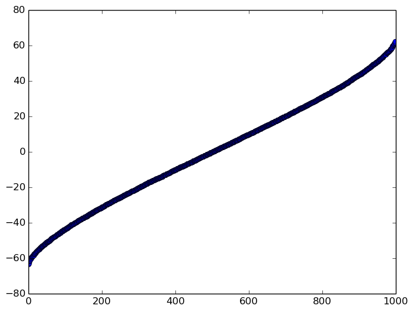

```
1-element Array{Any,1}:
 PyObject <matplotlib.lines.Line2D object at 0x7ff8f8bd3390>
```

```python
plot(lamb, "o-")
```

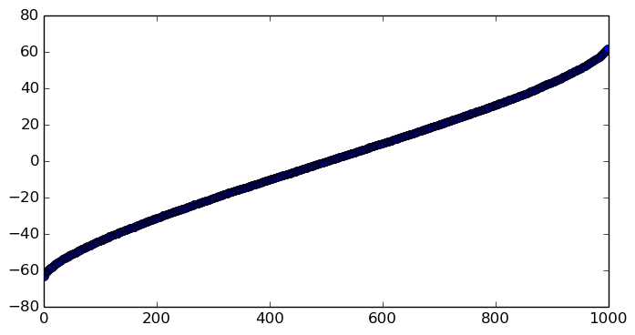

```
1-element Array{Any,1}:
 PyObject <matplotlib.lines.Line2D object at 0x7ff8f8a19310>
```

```python
PyPlot.figure(figsize=(8,4))
plot(lamb, "o-")
```

```python
differences = diff(lamb);
```

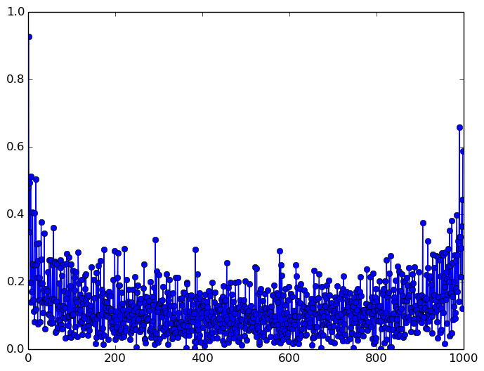

```
1-element Array{Any,1}:
 PyObject <matplotlib.lines.Line2D object at 0x7ff8f89d3650>
```

```python
plot(differences, "o-")
```

```python
h = hist(differences, 100)
```

```
(0.0:0.01:0.93,[8,16,23,48,47,54,59,56,54,66  …  0,0,0,0,0,0,0,0,0,1])
```

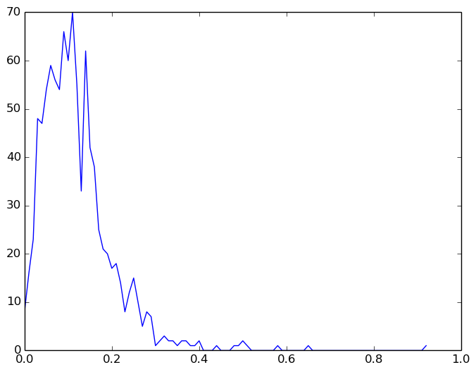

```
1-element Array{Any,1}:
 PyObject <matplotlib.lines.Line2D object at 0x7ff8f88ed850>
```

```python
plot(collect(h[1][1:end-1]), h[2])
```

```python
g.particles
```

```
type Function has no field particles
while loading In[262], in expression starting on line 1
```

```python
for particle in g.particles
    move(particle, 1)
end

g.particles
```

```
type Function has no field particles
while loading In[263], in expression starting on line 1

 in anonymous at no file
```